« back

# Installing Python modules on PAWS Internal

Madhu said that the global version of `pip` is out of data and needs to be updated on a per-user basis.

> Upgrading should get you to pip 8+, and then wheels (the new python distribution format) instead of eggs should get installed.

You can update & install within the notebook, but if you prefer to do it in Terminal after SSH'ing to notebook1001.eqiad.wmnet, you can add the path to your **~/.bash_profile**:

```
[[ -r ~/.bashrc ]] && . ~/.bashrc
export PATH=${PATH}:~/venv/bin
export http_proxy=http://webproxy.eqiad.wmnet:8080
export https_proxy=http://webproxy.eqiad.wmnet:8080
```

Then you can use and upgrade `pip`:

```python
!pip install --upgrade pip
```

```
Downloading/unpacking pip from https://pypi.python.org/packages/b6/ac/7015eb97dc749283ffdec1c3a88ddb8ae03b8fad0f0e611408f196358da3/pip-9.0.1-py2.py3-none-any.whl#md5=297dbd16ef53bcef0447d245815f5144
  Found existing installation: pip 1.5.6
    Uninstalling pip:
      Successfully uninstalled pip
Cleaning up...
```

Then we can install (for example):

- **Data**
  - [Pandas](http://pandas.pydata.org/) for analysis-friendly data structures (e.g. Series & DataFrame)
  - [Pandas Data Reader](https://github.com/pydata/pandas-datareader) for remote data access in Pandas
  - [Requests](http://www.python-requests.org/en/master/) for HTTP requests
  - [BeautifulSoup](https://www.crummy.com/software/BeautifulSoup/) for web-scraping
  - [Feather](https://github.com/wesm/feather/tree/master/python) is an [Apache Arrow](https://arrow.apache.org/)-based file format that efficiently stores pandas DataFrame objects on disk. **Note**: You can read/write feather files into/out of R using the [sister R interface](https://github.com/wesm/feather/tree/master/R) (available [on CRAN](https://cran.r-project.org/package=feather)).
- **Visualization**
  - [Seaborn](http://seaborn.pydata.org/) for data visualization (also installs [Matplotlib](http://matplotlib.org/)):
  - [Bokeh](http://bokeh.pydata.org/en/latest/) for interactive dataviz
- **Statistical Modeling and Machine Learning**
  - [StatsModels](http://statsmodels.sourceforge.net/) for statistical analysis
  - [Scikit-Learn](http://scikit-learn.org/stable/) for machine learning
  - [hyperopt-sklearn](http://hyperopt.github.io/hyperopt-sklearn/) for hyper-parameter optimization and finding the best classifier
  - sklearn-pandas provides a bridge between [Scikit-Learn](http://scikit-learn.org/stable/)'s machine learning methods and [pandas](http://pandas.pydata.org/)-style Data Frames
  - [PyStan](http://mc-stan.org/interfaces/pystan) interface to Stan probabilistic programming language for Bayesian inference
  - [PyMC3](http://pymc-devs.github.io/pymc3/) for Bayesian modeling and probabilistic machine learning
  - [Patsy](https://github.com/pydata/patsy) for describing statistical models (especially linear models, or models that have a linear component) and building design matrices. (Patsy brings the convenience of R "formulas" to Python)
  - [TensorFlow](https://www.tensorflow.org/) for machine learning using data flow graphs
  - [Edward](http://edwardlib.org/) for probabilistic modeling, inference, and criticism (uses PyMC3 and TensorFlow)

```
pip install \
    pandas pandas-datareader requests beautifulsoup4 feather-format \
    seaborn bokeh \
    statsmodels scikit-learn hyperopt sklearn-pandas pystan pymc3 patsy
```

**Warning**: Install [TensorFlow v1.0](https://www.tensorflow.org/versions/r1.0/get_started/) specifically:

```
export TF_BINARY_URL=https://storage.googleapis.com/tensorflow/linux/cpu/tensorflow-1.0.0rc2-cp34-cp34m-linux_x86_64.whl
pip install $TF_BINARY_URL
pip install edward
```

## Testing, 1, 2, 3

Let's check that things work!

```python
import seaborn as sns
iris = sns.load_dataset('iris')
iris.head()
```

|  | sepal_length | sepal_width | petal_length | petal_width | species |
| --- | --- | --- | --- | --- | --- |
| 0 | 5.1 | 3.5 | 1.4 | 0.2 | setosa |
| 1 | 4.9 | 3.0 | 1.4 | 0.2 | setosa |
| 2 | 4.7 | 3.2 | 1.3 | 0.2 | setosa |
| 3 | 4.6 | 3.1 | 1.5 | 0.2 | setosa |
| 4 | 5.0 | 3.6 | 1.4 | 0.2 | setosa |

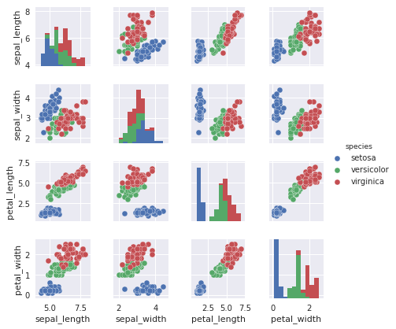

```python
%matplotlib inline
import seaborn as sns; sns.set()
sns.pairplot(iris, hue='species', size=1.5);
```

## Updating installed modules

This nifty command comes to us courtesy of [rbp at Stack Overflow](http://stackoverflow.com/a/3452888/1091835):

```
pip freeze --local | grep -v '^\-e' | cut -d = -f 1  | xargs -n1 pip install -U
```